# To tape or not to tape

Michel de Lange

28/11/2019

```r
df <- read.csv('~/Documents/plaster/Adhesive Study Complete Dataset.csv',header=T)
num.start <- length(unique(df$participant_id))

df <- df[which(df$q_complete == 1),]
df <- df[which(df$sensor_loss %in% c(0,1)),]
df <- df[which(df$patch_use %in% c(0,1)),]

df$patch_use <- factor(df$patch_use)
df$sensor_loss <- factor(df$sensor_loss)

num.part <- length(unique(df$participant_id))
```

We have a total of 34 participants. Two participants did not return any complete questionaires, so we are left with 32 participants Between them, these 32 people returned 314 complete questionaires, i.e 9.8 on average. Each questionaire contains a single answer (patch lost or not), and the main variable of interest is whether the participants were using a plaster. Let’s cross-table this:

```r
m <- data.frame(sensor_loss=df$sensor_loss,patch_use = df$patch_use)
t <- table(m)
addmargins(t,margin=c(1,2))
```

```
##            patch_use
## sensor_loss   0   1 Sum
##         0   167  89 256
##         1    35  23  58
##         Sum 202 112 314
```

```r
propLost <- round(100*sum(t[2,]/sum(t)),0)
t2 <- round(prop.table(t),2)
addmargins(t2,margin=c(1,2))
```

```
##            patch_use
## sensor_loss    0    1  Sum
##         0   0.53 0.28 0.81
##         1   0.11 0.07 0.18
##         Sum 0.64 0.35 0.99
```

```r
f <- fisher.test(table(df$sensor_loss,df$patch_use))
```

We have 167 (53 % of all) questionaires, where the sensor was not lost and no patch was not worn; There are 89 instances where the patch was used and the sensor was not lost, and so on. The sensor was reported lost in 18 % of all surveys.

Let’s show the percentages by patch use:

```r
t3 <- round(prop.table(t,margin=2),2)
addmargins(t3,1)
```

```
##            patch_use
## sensor_loss    0    1
##         0   0.83 0.79
##         1   0.17 0.21
##         Sum 1.00 1.00
```

We can do Fisher’s exact test to tell us whether there is any evidence for a relationship between patch use and sensor loss. Here are the results:

```r
fisher.test(table(df$sensor_loss,df$patch_use))
```

```
##
##  Fisher's Exact Test for Count Data
##
## data:  table(df$sensor_loss, df$patch_use)
## p-value = 0.5441
## alternative hypothesis: true odds ratio is not equal to 1
## 95 percent confidence interval:
##  0.6522102 2.2959644
## sample estimates:
## odds ratio
##   1.232209
```

We see that the confidence interval includes the value 1, and we have no evidence for a relationship between patch use and plaster loss.

This analysis disregards lack of independence between observations. We have on average 10 questionaires for each participant. We can reasonably expect factors leading to sensor loss and patch use, to be correlated for the same individual, and hence Fisher’s exact test is not appropriate. It is, however, a good first shot for looking at the relationship between patch use and sensor loss.

Let’s look at our data. The plot below shows the proportion of sensor loss for each participant. The red dots represent proportions of sensor loss when wearing a patch. The blue dots are proportions of sensor loss, when not wearing the patch. Dot size indicates the sample size. The bigger the dot, the more surveys we had for this person/patch-use.

```r
p.nopatch <- vector()
p.patch <- vector()
n.patch <- vector()
n.nopatch <- vector()
pers <- vector()
participants <- unique(df$participant_id)
for (i in 1:length(participants)) {
  p1 <- participants[i]
  y.patch <- df[which(df$participant_id==p1 & df$patch_use==1),"sensor_loss"]
  y.nopatch <- df[which(df$participant_id==p1 & df$patch_use==0),"sensor_loss"]
  n.patch[i] <- length(y.patch)
  n.nopatch[i] <- length(y.nopatch)
  y.patch <- as.numeric(as.character(y.patch))
  y.nopatch <- as.numeric(as.character(y.nopatch))
  p.patch[i] <- sum(y.patch)/n.patch[i]
  p.nopatch[i] <- sum(y.nopatch)/n.nopatch[i]
  pers[i] <- toString(p1)
}
df.prop <- data.frame(p.patch = p.patch,
                     p.nopatch = p.nopatch,
                     pers = pers,
                     n.patch = n.patch,
                     n.nopatch = n.nopatch)
dim(df.prop)
```

```
## [1] 32  5
```

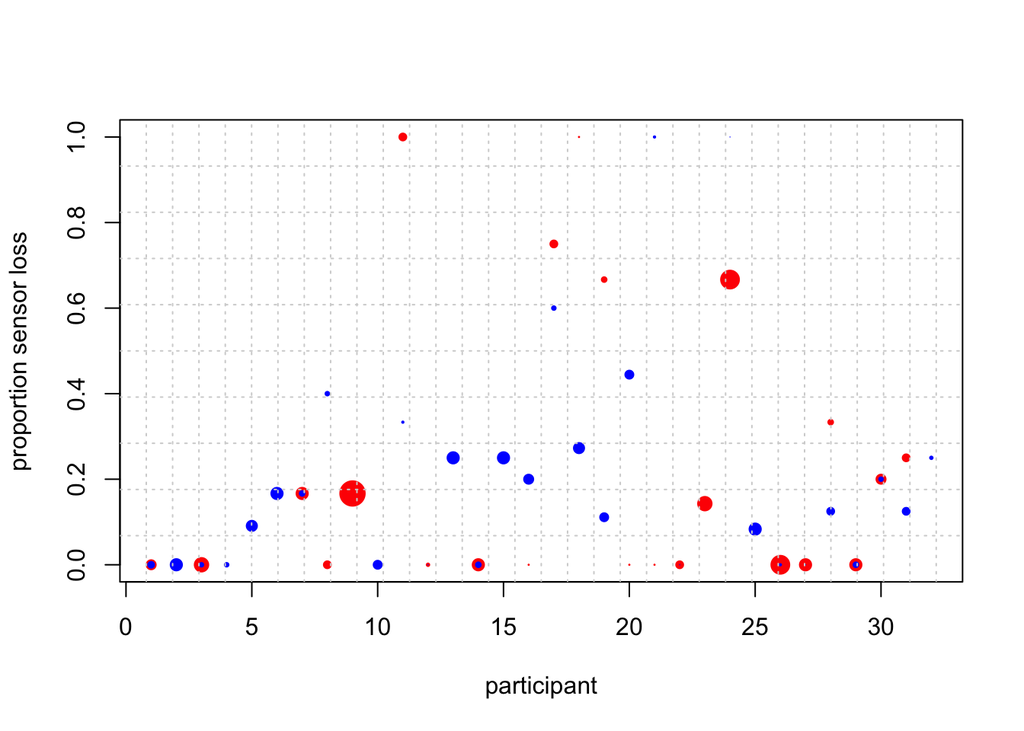

```r
{
plot('',xlim=c(1,32),ylim=c(0,1),xlab='participant',
     ylab='proportion sensor loss')
points((1:32),df.prop$p.patch,col='red',pch=16,cex=df.prop$n.patch/5)
points((1:32),df.prop$p.nopatch,col='blue',pch=16,cex=df.prop$n.nopatch/10)
grid(nx=32,ny=10)
}
```

```r
#df[which(df$participant_id==p1),c("sensor_loss",'patch_use')]
l1 <- which(p.patch < p.nopatch)
l2 <- which(p.patch > p.nopatch)
l3 <- which(p.patch == p.nopatch)
```

There are 5 participants with lower proportion of loss when wearing a patch. There are 6 participants with a higher proportion of losses when using a patch. The proportion is unchanged ror 11 participants. We can see here that doing a paired t-test on the change in proportion (as discussed) is not going to be a good idea. Participant 18, for instance, lost 100% of his sensors when wearing a patch, and only a third of them when not wearing it. However, this person did not wear the patch 11 times, while the figure of 100% is based on a single observation. Nevertheless, it is clearly not jumping out at us that wearing a patch is preventing sensor loss.

## linear mixed model

There could be confounders: Things which influence sensor loss, which cancel each other out, so we don’t see them in the 2-way table. We can overcome these two problems (lack of independence, caused by repeated observations on the same individual, and confounding), by fitting a linear mixed model. The response variable will be patch loss, and the predictor variable will be -in the first instance- patch use. We can add demographic variables, and whatever else we may have at hand, to check for confounding. The thing of interest will be the confidence interval for the odds ratio (odds of losing a sensor when wearing a patch / odds of losing a sensor when not wearing a patch).

```r
library(lme4)
m <- glmer(sensor_loss ~ patch_use + (1|participant_id),
    family='binomial',data=df)
s <- summary(m)
lower <- round(exp(s$coefficients[2,1] - 2*s$coefficients[2,2]),1)
upper <- round(exp(s$coefficients[2,1] + 2*s$coefficients[2,2]),1)
```

If we just use patch use as the only predictor variable, this confidence interval for the odds ratio will be from 0.6 to 2.8. This includes the value 1, so we have no evidence for an effect of patch use. We can include other available predictors, such as sex, the nz deprivation group.

```r
df$nzdepgroup <- 'LOW'
df[which(df$nzdep %in% c(4,5,6,7)),'nzdepgroup'] <- "MEDIUM"
df[which(df$nzdep %in% c(8,9,10)),'nzdepgroup'] <- "HIGH"
df$nzdepgroup <- factor(df$nzdepgroup)
df$nzdepgroup <- relevel(df$nzdepgroup,ref='LOW')
df$sex <- factor(df$sex)
df$phase <- factor(df$phase)

m <- glmer(sensor_loss ~ sex + nzdepgroup + phase + patch_use +
             (1|participant_id),
           family='binomial',data=df)
#summary(m)
exp(confint(m))
```

```
## Computing profile confidence intervals ...
```

```
##                       2.5 %    97.5 %
## .sig01           1.97299894 7.0442901
## (Intercept)      0.06668070 0.6027786
## sex2             0.31037785 3.7244129
## nzdepgroupHIGH   0.08821554 2.4847207
## nzdepgroupMEDIUM 0.22992662 3.8588152
## phase2           0.32601501 1.2361180
## patch_use1       0.49325875 2.5112147
```

We see that all confidence intervals for the odds ratios include the value 1. Nothing is significant, and the CI for patch use is similar to what we had before. So far, we have no evidence for an effect of patch use on sensor loss.

The study phase was one of the predictors, so we can see that it makes no difference whether a participant is in phase 1 or phase 2. In a separate model, I put in the interaction of phase and patch-use, and this was also not significant. This shows that we cannot claim that the effect of patch use on sensor loss depends on which phase of the trial we are in.

##Compliance

Let’s see how compliant to the protocol our participants have been:

```r
dft <- data.frame(allocation=df$patch_allocation,use=df$patch_use)
t <- table(dft)
addmargins(t)
```

```
##           use
## allocation   0   1 Sum
##        0   118  34 152
##        1    84  78 162
##        Sum 202 112 314
```

```r
nrecs <- which(df$patch_allocation != df$patch_use)
non.comp <- unique(df[nrecs,"participant_id"])
con.comp.num <- length(non.comp)
```

So we have 34 surveys of people who used a patch while they should not, and 84 who did not wear a patch while they should. That’s 118 non-compliant surveys, or 38 % of surveys. These non-compliant surveys came from 29 people. Hence, almost none of our participants have fully complied with the protocol. On the positive side, Fisher’s exact test on this table does show that there is a relationship between the protocol and what people actually do :)

In Intention to Treat analysis, we allocate people according to what they should have done, rather than to what they actually did. This would tell us something about the effect of telling someone to wear a patch (as opposed to the effect of wearing one.) We can repeat the linear mixed model from above, but use patch allocation as the predictor, rather than patch use.

```r
m <- glmer(sensor_loss ~ sex + nzdepgroup + phase + patch_allocation +
             (1|participant_id),
           family='binomial',data=df)
#summary(m)
exp(confint(m))
```

```
## Computing profile confidence intervals ...
```

```
##                       2.5 %    97.5 %
## .sig01           2.00094670 7.2399575
## (Intercept)      0.05775809 0.5379575
## sex2             0.30629289 3.7590209
## nzdepgroupHIGH   0.08421680 2.4784643
## nzdepgroupMEDIUM 0.23168831 3.8820316
## phase2           0.27205649 1.1095197
## patch_allocation 0.75687287 3.0623674
```

We see that this does not change the conclusion: The confidence interval for patch allocation contains the value 1, and so there is no significant relationship between patch allocation and sensor loss.

In Per Protocol analysis, we remove all 118 non compliant records, leaving us with 196 surveys. We can hardly remove all records for anyone, who did not fully comply, because we would have almost no records left.

[output not shown]

```
## Computing profile confidence intervals ...
```

```
##                       2.5 %    97.5 %
## .sig01           1.00000000 4.7905119
## (Intercept)      0.09013404 0.6563178
## sex2             0.46613168 4.9511854
## nzdepgroupHIGH   0.04724857 1.0359211
## nzdepgroupMEDIUM 0.08602020 1.2776277
## phase2           0.31793345 2.3279650
## patch_use1       0.67908046 4.3605024
```

Again, patch use is not significant.

## Conclusions

The sensor was reported lost in 18 % of surveys. We have found no evidence that patches prevent sensor loss. This is the case for intention to treat analysis, per protocol analysis, or when we allocate people to what they actually did.